# R Reference Guide

Feipeng Huang

## Loading Data and Packages

Load the here and palmerpenguins packages

```r
library(here)
require(here)
library(palmerpenguins)
require(palmerpenguins)
```

```r
ginkgo = read.csv(here("data", "ginkgo_data_2022.csv"))
```

## Data Structures

The function c() combines or concatenates its arguments into a vector (a 1-dimensional data structure consisting of 1 or more elements).  
All of the elements must be of the same type.  
I can’t combine character and numeric types in the same call to c()  
Here’s two examples using numeric and character data types:

```r
## Create a vector of numbers:
num_vec  = c(1, 4, 8, 9, 13)
```

```r
## Create a vector of characters:
char_vec = c("a", "fish", "data is cool")
```

I can show the contents of a vector by typing the name of the vector, or using the print() function.

```r
## Typing the name of the vector into the console prints the contents
num_vec
```

```
## [1]  1  4  8  9 13
```

```r
## The print() function accomplishes the same task:
print(char_vec)
```

```
## [1] "a"            "fish"         "data is cool"
```

The length of num_vec

```r
length(num_vec)
```

```
## [1] 5
```

A **matrix** must contain the same data type  
A matrix with 2 rows and 4 columns that contain the number 1 to 8, filled by row

```r
matrix(1:8, nrow = 2, ncol = 4, byrow = TRUE)
```

```
##      [,1] [,2] [,3] [,4]
## [1,]    1    2    3    4
## [2,]    5    6    7    8
```

filled by columns

```r
matrix(1:8, nrow = 2, ncol = 4, byrow = FALSE)
```

```
##      [,1] [,2] [,3] [,4]
## [1,]    1    3    5    7
## [2,]    2    4    6    8
```

A **data frame** can contain different data types  
A data frame with Hudsonian Godwit chick ID and mass (g)

```r
ID = c("H38", "H88", "H79", "H15")
mass = c(25, 24, 22, 24)
HUGO_mass = data.frame(ID, mass)
HUGO_mass
```

```
##    ID mass
## 1 H38   25
## 2 H88   24
## 3 H79   22
## 4 H15   24
```

The number of rows in ginkgo data.frame

```r
nrow(ginkgo)
```

```
## [1] 220
```

The number of columns in ginkgo data.frame

```r
ncol(ginkgo)
```

```
## [1] 6
```

The dimension of ginkgo data.frame

```r
dim(ginkgo)
```

```
## [1] 220   6
```

## Subsetting

Subset by **name**

```r
## select site_id column in ginkgo data.frame
ginkgo$site_id
```

```
##   [1]   216   216   216   216   216   216   216   216   216   216  1896  1896
##  [13]  1896  1896  1896  1896  1896  1896  1896  1896  2183  2183  2183  2183
##  [25]  2183  2183  2183  2183  2183  2183  2187  2187  2187  2187  2187  2187
##  [37]  2187  2187  2187  2187  3469  3469  3469  3469  3469  3469  3469  3469
##  [49]  3469  3469  3470  3470  3470  3470  3470  3470  3470  3470  3470  3703
##  [61]  3703  3703  3703  3703  3703  3703  3703  3703  3703  3704  3704  3704
##  [73]  3704  3704  3704  3704  3704  3704  3704  3705  3705  3705  3705  3705
##  [85]  3705  3705  3705  3705  3705  4847  4847  4847  4847  4847  4847  4847
##  [97]  4847  4847  4847  4873  4873  4873  4873  4873  4873  4873  4873  4873
## [109]  4873  4874  4874  4874  4874  4874  4874  4874  4874  4874  4874  6066
## [121]  6066  6066  6066  6066  6066  6066  6066  6066  6066  6069  6069  6069
## [133]  6069  6069  6069  6069  6069  6069  6069  6069  6071  6071  6071  6071
## [145]  6071  6071  6071  6071  6071  6071  6718  6718  6718  6718  6718  6718
## [157]  6718  6718  6718  6718  6719  6719  6719  6719  6719  6719  6719  6719
## [169]  6719  6719  6721  6721  6721  6721  6721  6721  6721  6721  6721  6721
## [181]  9603  9603  9603  9603  9603  9603  9603  9603  9603  9603 12669 12669
## [193] 12669 12669 12669 12669 12669 12669 12669 12669 12978 12978 12978 12978
## [205] 12978 12978 12978 12978 12978 12978 12982 12982 12982 12982 12982 12982
## [217] 12982 12982 12982 12982
```

Subset by **position**

```r
## select first row of the ginkgo data
ginkgo[1,]
```

```
##   site_id seeds_present max_width max_depth notch_depth petiole_length
## 1     216         FALSE        85        59          12             91
```

```r
## select the element in row 2, column 3
ginkgo[2,3]
```

```
## [1] 72
```

```r
## select the 3rd column of the ginkgo data
ginkgo[,3]
```

```
##   [1]  85  72  64  76  85  75  72  81  87  87  94  92  70  84  61 102  82  64
##  [19]  53  66  69  55  56  64  60  59  57  53  68  56  75  63  82  83  60  67
##  [37]  75  92 110  54  77  59  51 100  92  77  99  62  80  86  63  79  91  72
##  [55]  64  53  71  61  70  93  75  87  86  87  95  88  85  95  95  52  84  74
##  [73]  87  76  57  92  94  79  97  50 100  97  63  96  97  70  83  80  85 100
##  [91] 112 115  83 106  95  80 120  76  50  90  94  69  93  59  60 103  95  90
## [109]  80  90 106  98  73  89  65  83 116  90  86 104  92 103 100  91 102  99
## [127]  98 104  80  68  62  77  86  72  70  63  72  65  69  67  35  67  63  71
## [145]  77  60  70  69  55  72  84 106  61 114  95  86  60  78  86  91  79  95
## [163]  72 102  72 107  95  91  94  90  98  63  58  67  92  75  74  73  73  94
## [181]  76  86  78  74  89  77  80  71  69  81  39  60  50  47  52  61  56  45
## [199]  64  42 103  84 118 120 100 111 104  94  78  70  92  48  79  91 111  44
## [217] 117  93 101 145
```

Retrieve all the data for Adelie penguins (in the species column) from the peuguins dataset

```r
Adelie = subset(penguins, species == "Adelie")
```

## Numerical Data Exploration

Summary of the ginkgo data

```r
summary(ginkgo)
```

```
##     site_id      seeds_present     max_width        max_depth
##  Min.   :  216   Mode :logical   Min.   : 35.00   Min.   : 24.0
##  1st Qu.: 3470   FALSE:180       1st Qu.: 67.00   1st Qu.: 45.0
##  Median : 4874   TRUE :40        Median : 80.00   Median : 53.0
##  Mean   : 5726                   Mean   : 79.95   Mean   : 53.1
##  3rd Qu.: 6719                   3rd Qu.: 93.00   3rd Qu.: 60.0
##  Max.   :12982                   Max.   :145.00   Max.   :125.0
##   notch_depth     petiole_length
##  Min.   : 0.000   Min.   : 13.00
##  1st Qu.: 0.000   1st Qu.: 45.00
##  Median : 2.000   Median : 58.00
##  Mean   : 5.977   Mean   : 59.51
##  3rd Qu.: 6.250   3rd Qu.: 71.00
##  Max.   :92.000   Max.   :126.00
```

Mean of ginkgo petiole length

```r
mean(ginkgo$petiole_length)
```

```
## [1] 59.50909
```

Standard deviation of ginkgo petiole length

```r
sd(ginkgo$petiole_length)
```

```
## [1] 21.04778
```

**Use na.rm = TRUE to exclude NA values if needed**

## Graphical Data Exploration

**Scatterplot**

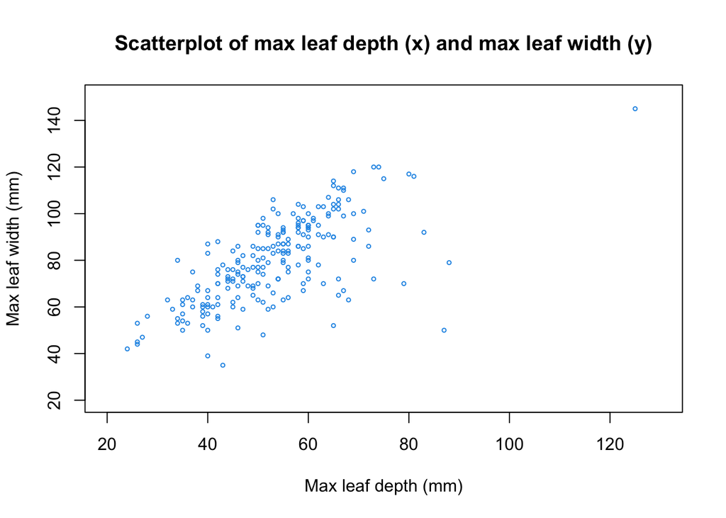

```r
## use col to set point color
## use pch to set point shape
## use cex to set point size
## use main to set title
## use xlab and ylab to set x-axis and y-axis labels
## use xlim and ylim to set x-axis and y-axis limits
plot(max_width ~ max_depth, data = ginkgo, col = 4, pch = 1, cex = 0.5, main = "Scatterplot of max leaf depth (x) and max leaf width (y)", xlab = "Max leaf depth (mm)", ylab = "Max leaf width (mm)", xlim = c(20,130), ylim = c(20,150))
```

**Histogram**

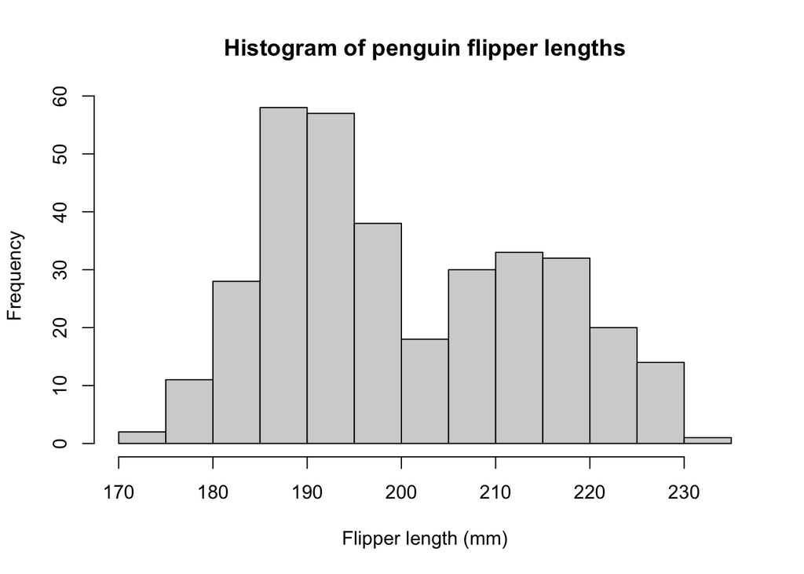

```r
## Use breaks to set the start and end points of each bin
hist(penguins$flipper_length_mm, breaks = seq(170, 235, by = 5), main = "Histogram of penguin flipper lengths", xlab = "Flipper length (mm)")
```

**Boxplot**

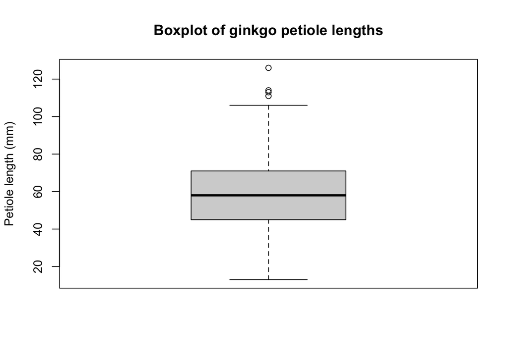

```r
boxplot(ginkgo$petiole_length, main = "Boxplot of ginkgo petiole lengths", ylab = "Petiole length (mm)")
```